# Activity-Read data and examine distributions

JB

updated 3/17/2021

*working format*

1. *JB gives brief intro (<10min) to activity (how to locate materials, what packages are used, new tools/functions that are used)*
2. *Instructors then walk the room to help with problems, provide explanation, etc.*
3. *Brief sum-up (what was learned, common problems encountered) led by JB (10minutes?)*

## Learning Objectives

- Set up a project directory and create an R markdown file (*.Rmd) to document your work
- Read data from different file formats
- Examine variables and characterize their distributions using simple visuals:
  - histogram
  - quantile-quantile plot
  - box plot
  - use a normality test (shapiro-wilk)

## Step 1 - Get organized.

[Video resource (Prof Andy Field) - Working in RStudio](http://milton-the-cat.rocks/learnr/r/r_getting_started/#section-working-in-rstudio) - watch the video if you want a review

#### 1.1 Set up a typical project work flow consisting of a project folder containing:

- *.Rproj file
- “r_docs” folder to store your lab notes in R markdown
- “data” folder to store data files for this activity
- “images” folder to store plots

#### 1.2 Start a new R markdown document to save your work on this activity

- name it something sensible
- in the “setup” code chunk load these packages with the `library()` function:
  - tidyverse, readr, ggplot2
- also in the “setup” chunk, paste in the line below (sets the base directory for knitr):
  - `knitr::opts_knit$set(root.dir = rprojroot::find_rstudio_root_file())`
- run the setup chunk (click the play button in the top right of the chunk) - this action will load the libraries that will be used below
  - if you get an error that “there is no package called blahblahblah” then you either have a typo (remember R is case-sensitive), or you need to install the package (in the console type, e.g., `install.packages("tidyverse")` or use the “Tools” menu)

## Step 2 - Import datasets for this activity

#### 2.1 download the files “ice_bucket.csv”, “nhanes_selectvars_n500.csv”, and “cort-hypothetical.txt” (right-click, save as) and move each to the “data” folder in your project

Here’s a description of the ice bucket data from [Andy Field’s discovr tutorial 02](https://www.discovr.rocks/discovr/):  
*The ice bucket challenge generated something like 2.3 million videos on YouTube. The data are stored in a csv file, which contains one variable **upload_day** that is the number of days after Chris Kennedy’s initial challenge that each of 2,323,452 ice bucket related videos were uploaded to YouTube. For example, if the value is 21 it means that the video was uploaded 21 days after Chris Kennedy’s initial challenge.*

Here is a link to [description of the NHANES variables in the full dataset](https://www.rdocumentation.org/packages/NHANES/versions/2.1.0/topics/NHANES) - you are going to work with a small subset of cases and variables. The data in “cort-hypothetical.txt” is hypothetical salivary cortisol values (nmol/L) generated for this activity.

#### 2.2 Read the ice bucket data into R

- put the code to read the files in a new code chunk (name it “*Step2-load-datasets*” within your markdown file
- if you need a reminder of the readr functions, use File->Import Dataset->From text (readr) to generate the code through the RStudio menu

```r
ice_tib <- readr::read_csv("data/ice_bucket.csv")
nhanes_tib <- readr::read_csv("data/nhanes_selectvars_n500.csv")
cort_tib <- readr::read_delim("data/cort-hypothetical.txt", delim = "\t",na = "qns")
```

- Workflow : Insert a “code chunk” into your R markdown doc and put the code there, then **use the “play” button to run chunks of code as you go along**. Don’t “knit” the file until you want to see all your work in one html/pdf doc.
- **Don’t use the View() function in any of your markdown code chunks**- it will make “knitr” stall when you try to knit your final doc. Instead, just click on the variable in your environment window to look at the dataframe/tibble.

## Step 3 - Examine ice bucket data - frequency distribution

#### 3.1 Check out the frequency distribution of “upload_day”

3.1.2 Start a new code chunk called *Step3-ice-bucket-histogram*. Make a histogram using ggplot geom_histogram() with no arguments (leaving defaults). What does the warning message say? (Write your notes above the code chunk)

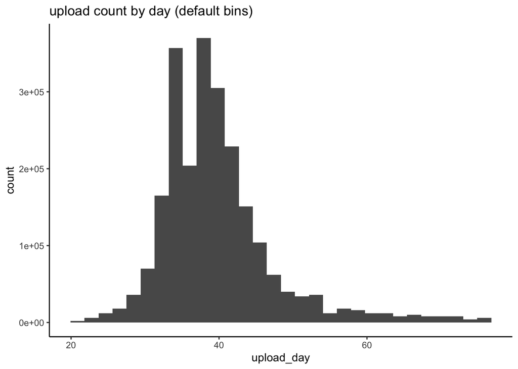

```r
p1 <- ice_tib %>%
      ggplot( aes(x=upload_day)) + geom_histogram() + theme_classic() +
        labs (title = "upload count by day (default bins)")
p1
```

3.1.3 Now, in the same code chunk, make the histogram again but set it to have 1 bin for each value of upload_day (you can use the `bins=`, `binwidth=`, or `breaks=` arguments in geom_histogram)

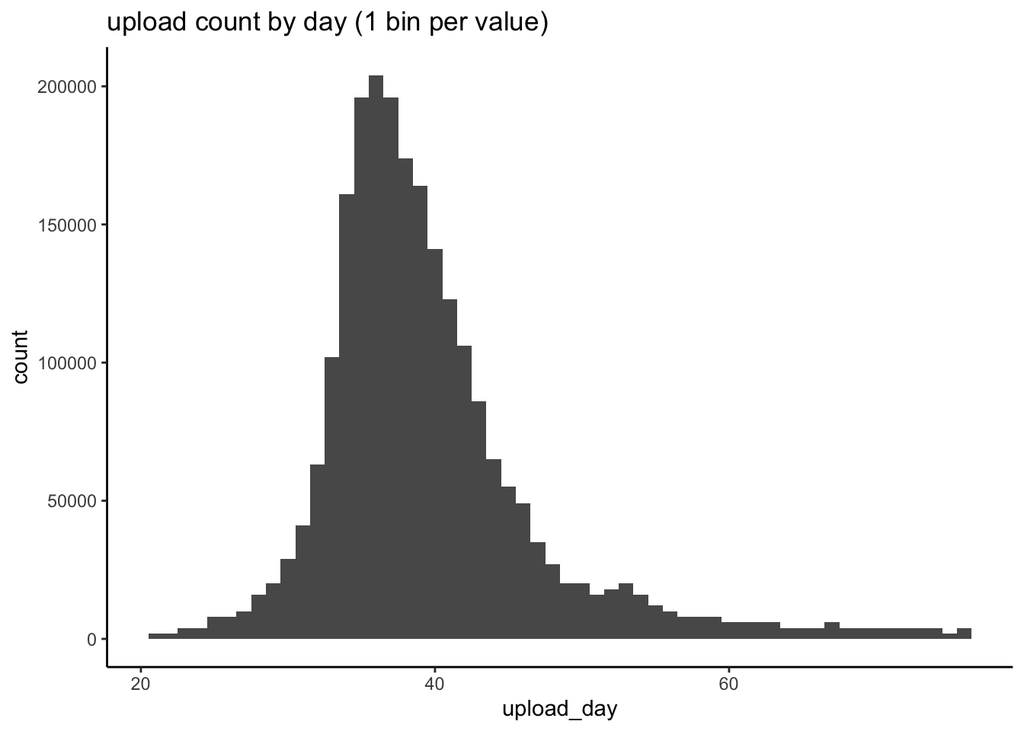

```r
p2 <- ice_tib %>%
      ggplot( aes(x=upload_day)) + geom_histogram(binwidth = 1) + theme_classic() +
        labs (title = "upload count by day (1 bin per value)")
p2
```

3.1.4 In the same code chunk, make the histogram again but set it to have 1 bin for upload_day values 20-29, 1 bin for values 30-39, …

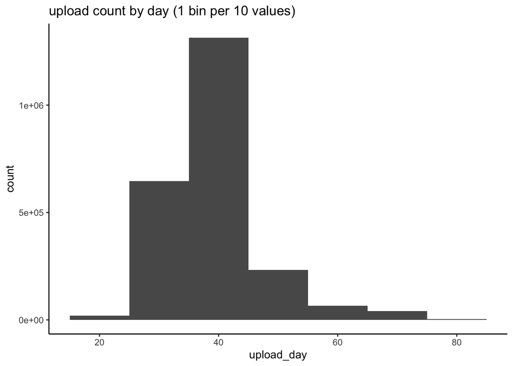

```r
p3 <- ice_tib %>%
      ggplot( aes(x=upload_day)) +
        geom_histogram(binwidth = 10) + #or use breaks = seq(20,80,by= 10)
        theme_classic() +
        labs (title = "upload count by day (1 bin per 10 values)")
p3
```

3.1.5 In your notes above the code chunk, describe the modality (how many peaks) and skew of the distribution.

3.1.6 Go back and give each plot a descriptive title, using `+ labs(title="my title")` in your code

## Step 4 - Examine NHANES data - outliers

#### 4.0 Read in NHANES data - insert the code in the chunk you created earlier called *“Step2-load-datasets”*

#### 4.1 Check out the distribution of “Height” - insert a code chunk (below Step3) called "*Step4.1-nhanes-height-all"* then put your notes above it

- Plot a histogram and a boxplot of “Height” (pick a sensible bin setting).
- Describe the distribution shape in your own words. Why does the boxplot show so many outliers at low values?
- Make a quantile-quantile plot of Height. Is Height normally distributed in this sample? Does this Q-Q plot look different from the SPSS one (pay attention to the axis labels)?
- Calculate the Shapiro-Wilk statistic for deviation from a normal distribution (use the function shapiro.test() on the Height data). What does it tell you?

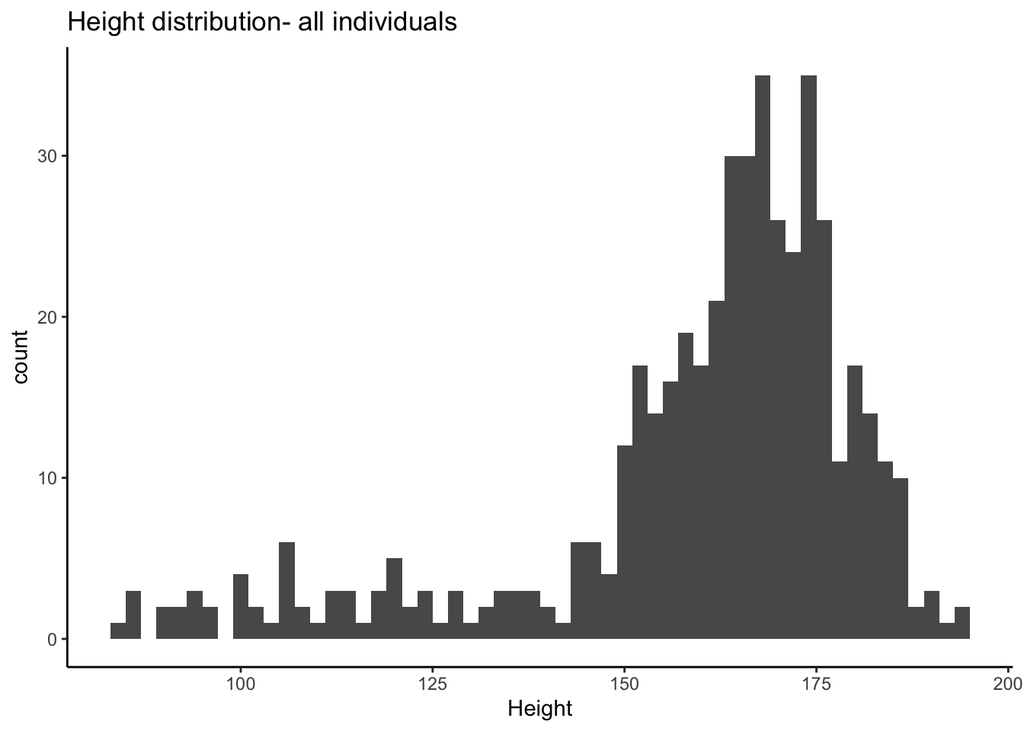

```r
p1 <- nhanes_tib %>% drop_na(Height) %>%
      ggplot( aes(x=Height)) + geom_histogram(binwidth=2) + theme_classic() +
        labs (title = "Height distribution- all individuals")
p1
```

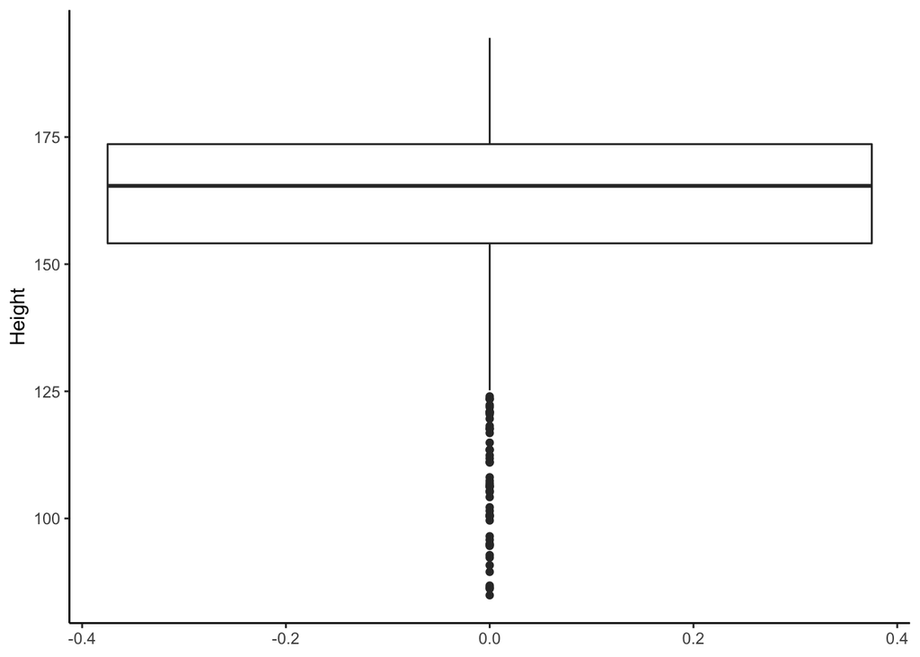

```r
p2 <- nhanes_tib %>% drop_na(Height) %>%
      ggplot( aes(y=Height)) + geom_boxplot() + theme_classic()
p2
```

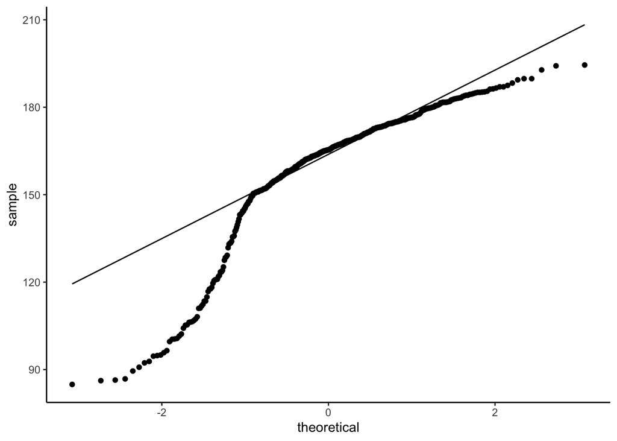

```r
p3 <- nhanes_tib %>% drop_na(Height) %>%
      ggplot( aes(sample=Height)) + geom_qq() + geom_qq_line() + theme_classic()
p3
```

```r
nhanes_tib %>% drop_na(Height) %>% {shapiro.test(.$Height)}
```

```
##
##  Shapiro-Wilk normality test
##
## data:  .$Height
## W = 0.84446, p-value < 2.2e-16
```

#### 4.2 Filter by Age - insert a new code chunk (call it *“Step4.2-nhanes-height-adults”*) and put your notes above it

- Now let’s restrict the plots to individuals age 18 or older, make a new histogram, box plot, and q-q plot of height using just those individuals (you can use the filter() or subset() function). Describe the distribution again in your own words.
- Re-calculate the Shapiro-Wilk statistic. What does it tell you?

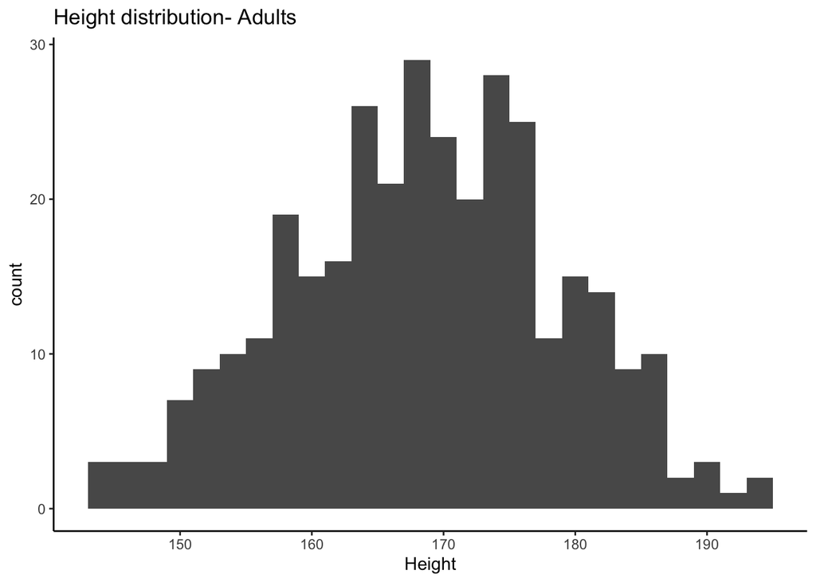

```r
p1 <- nhanes_tib %>% drop_na(Height) %>% filter(Age>=18) %>%
      ggplot( aes(x=Height)) + geom_histogram(binwidth=2) + theme_classic() +
        labs (title = "Height distribution- Adults")
p1
```

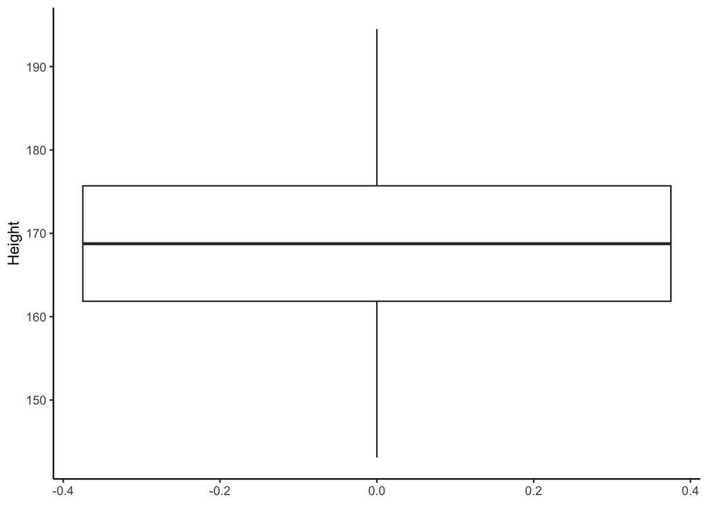

```r
p2 <- nhanes_tib %>% drop_na(Height) %>% filter(Age>=18) %>%
      ggplot( aes(y=Height)) + geom_boxplot() + theme_classic()
p2
```

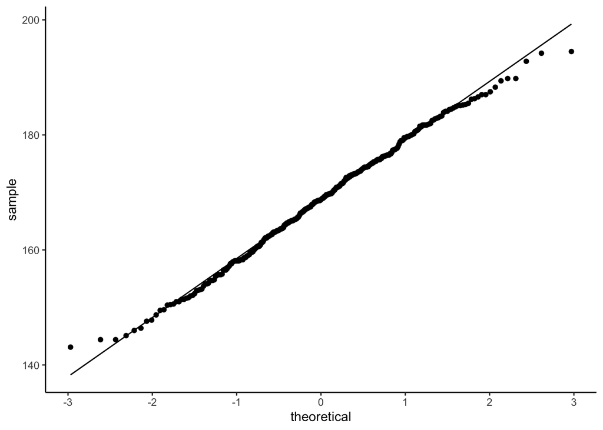

```r
p3 <- nhanes_tib %>% drop_na(Height) %>% filter(Age>=18) %>%
      ggplot( aes(sample=Height)) + geom_qq() + geom_qq_line() + theme_classic()
p3
```

```r
nhanes_tib %>% drop_na(Height) %>% filter(Age>=18) %>% {shapiro.test(.$Height)}
```

```
##
##  Shapiro-Wilk normality test
##
## data:  .$Height
## W = 0.99544, p-value = 0.4318
```

## Step 5 - Applying a mathematical transformation

#### 5.1 Imagine a subset (N=400) of the NHANES participants gave saliva samples The lab sent you a file “cort-hypothetical.txt” containing an ID and cortisol measurement on each line, separated by a tab (“\t”).

5.1.1 Read the text file into a new dataframe/tibble (write the code in the original *Step2-load-dataset* code chunk) - note that some values are “qns” which stands for “quantity not sufficient” and should be treated as missing values.

#### 5.2 Now check out the distribution of “cortisol_baseline” using what you’ve learned so far- insert a code chunk called "*Step5-cort"* .

5.2.1 Describe the distribution of cortisol_baseline in your notes.

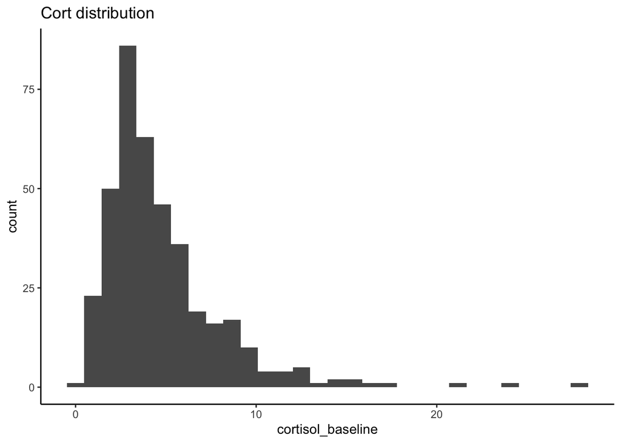

```r
p1 <- cort_tib %>% drop_na(cortisol_baseline) %>%
        ggplot( aes(x=cortisol_baseline)) +
        geom_histogram(bins=30) + theme_classic() +
        labs (title = "Cort distribution")
p1
```

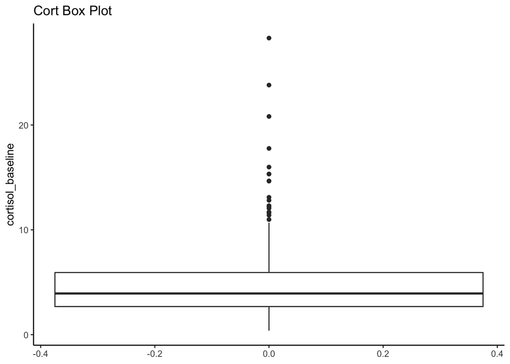

```r
p2 <- cort_tib %>% drop_na(cortisol_baseline) %>%
        ggplot( aes(y=cortisol_baseline)) + geom_boxplot() +
        theme_classic() + labs(title = "Cort Box Plot")
p2
```

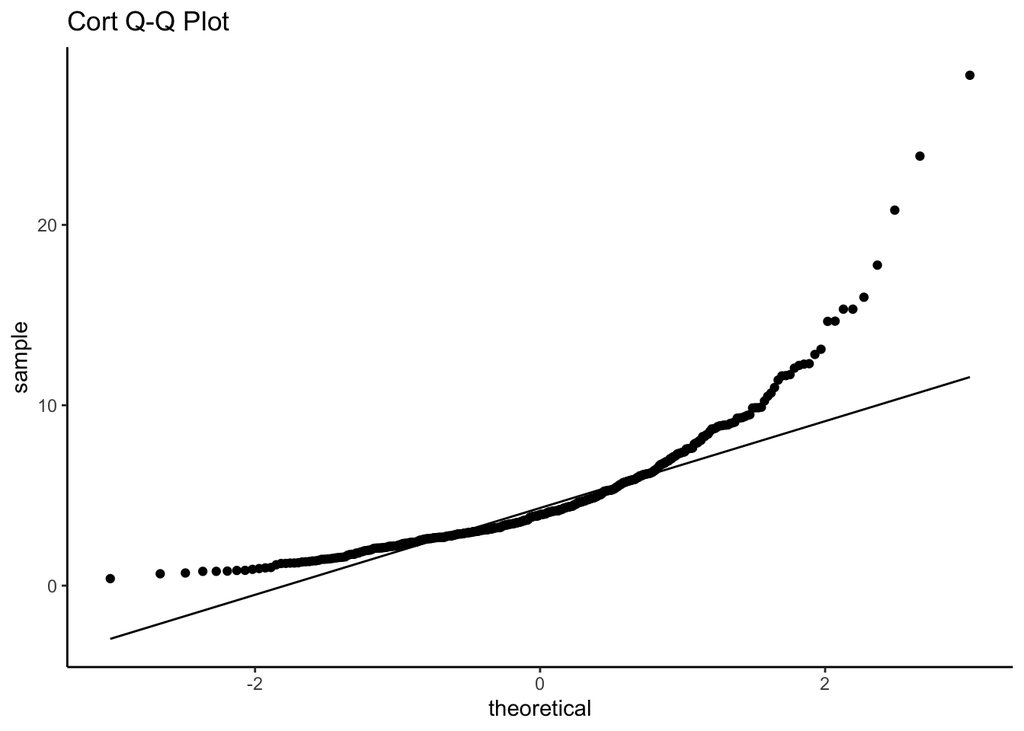

```r
p3 <- cort_tib %>% drop_na(cortisol_baseline) %>%
      ggplot( aes(sample=cortisol_baseline)) + geom_qq() +
      geom_qq_line() + theme_classic() +
      labs(title = "Cort Q-Q Plot")
p3
```

```r
cort_tib %>% drop_na(cortisol_baseline) %>% {shapiro.test(.$cortisol_baseline)}
```

```
##
##  Shapiro-Wilk normality test
##
## data:  .$cortisol_baseline
## W = 0.80483, p-value < 2.2e-16
```

#### 5.3 Log transformation of a variable can be useful for some measurements with positively skewed distributions, and it is a common practice with salivary cortisol.

5.3.1 Use the function “log” to create a new column in your cortisol dataframe, containing the natural logarithm of each cortisol_baseline measurement. Then, describe the distribution of the log-transformed cortisol_baseline.

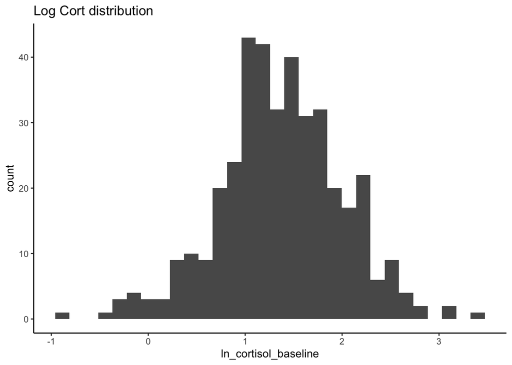

```r
cort_tib <- cort_tib %>%
              mutate(ln_cortisol_baseline=log(cortisol_baseline))
p1 <- cort_tib %>% drop_na(ln_cortisol_baseline) %>%
        ggplot( aes(x=ln_cortisol_baseline)) +
        geom_histogram(bins=30) + theme_classic() +
        labs (title = "Log Cort distribution")
p1
```

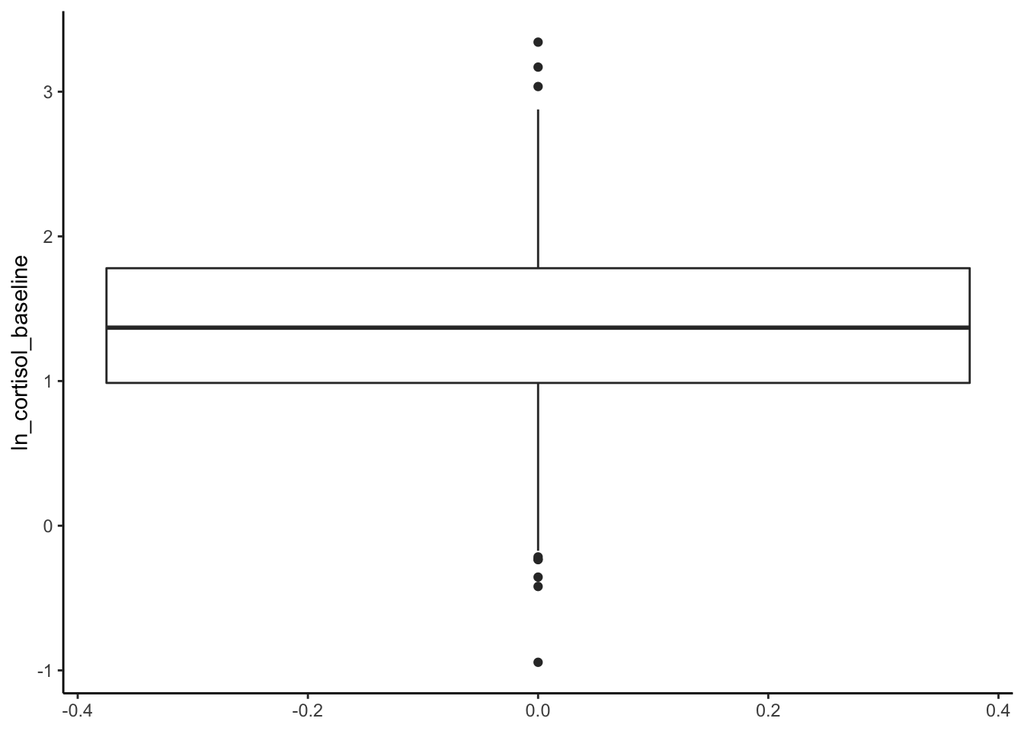

```r
p2 <- cort_tib %>% drop_na(ln_cortisol_baseline) %>%
        ggplot( aes(y=ln_cortisol_baseline)) + geom_boxplot() + theme_classic()
p2
```

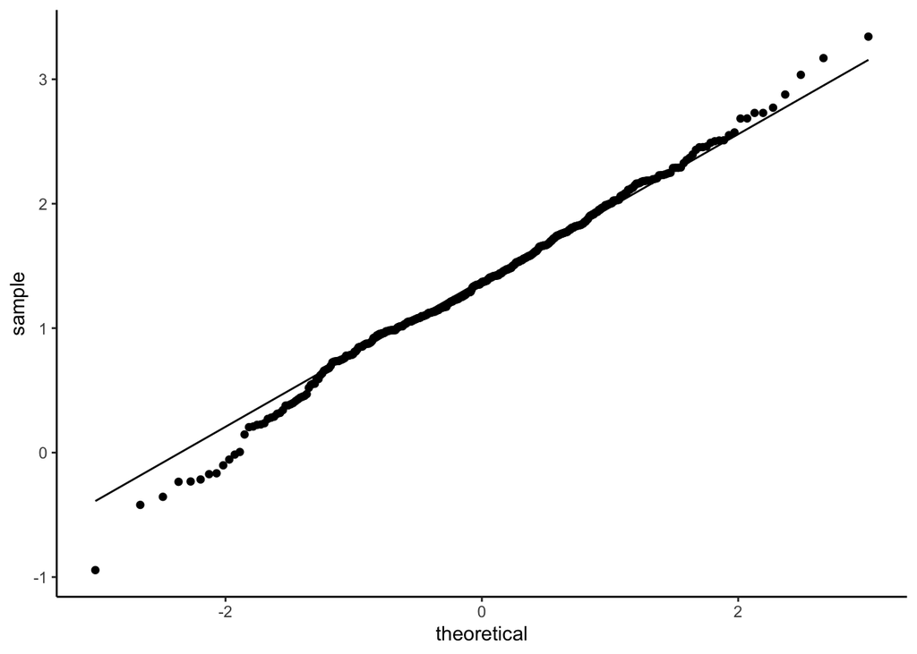

```r
p3 <- cort_tib %>% drop_na(ln_cortisol_baseline) %>%
        ggplot( aes(sample=ln_cortisol_baseline)) + geom_qq() +
        geom_qq_line() + theme_classic()
p3
```

```r
cort_tib %>% drop_na(ln_cortisol_baseline) %>% {shapiro.test(.$ln_cortisol_baseline)}
```

```
##
##  Shapiro-Wilk normality test
##
## data:  .$ln_cortisol_baseline
## W = 0.99414, p-value = 0.1394
```

## 6.0 Mini-challenge

- Now make a histogram and boxplot of Height from the NHANES data set, but group by Gender, so that you have 1 histogram plot (where different Genders get color-coded) and 1 boxplot (with Gender on the x-axis). Do you see any outliers (according to the boxplot threshold), when the data are split by Gender?
- Hints:
  - you can use the “fill” argument in `aes()`to map a variable onto the fill color chart component (called an “aesthetic” in ggplot language) - use position=“identity” and alpha=.5 so that the histogram bars for different Gender are overlayed (rather than stacked)
  - you can use the “x” axis argument in aes() to map a variable onto the x-axis (for the boxplot)
- **Things to pay attention to:** did you see a warning like “Removed {X} rows containing non-finite values” above the plots? What does that mean? How can you adjust your code so that you don’t get the warning?
- Experiment with different settings (position, alpha, theme) if you finish early

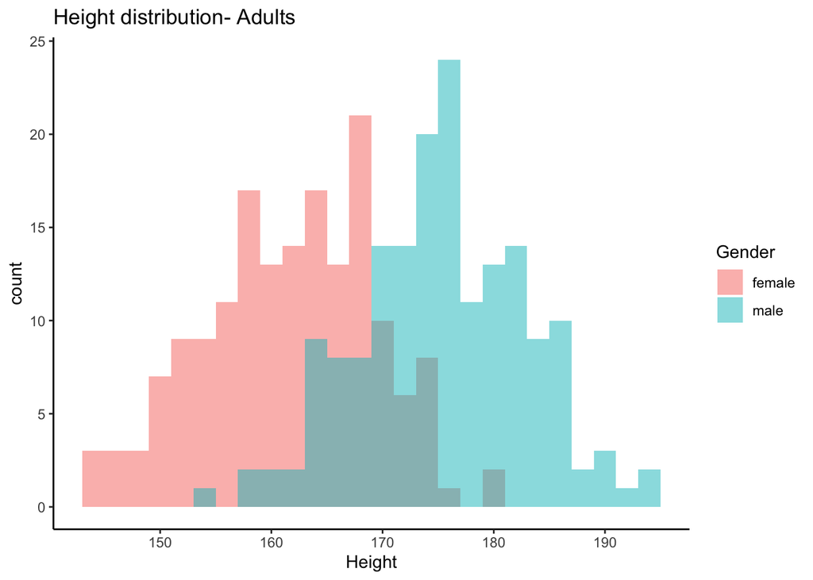

```r
p1 <- nhanes_tib  %>% drop_na(Height,Gender) %>% filter(Age>=18) %>%
      ggplot( aes(x=Height, fill=Gender)) +
        geom_histogram(position="identity",alpha=.5,binwidth=2) + theme_classic() +
        labs (title = "Height distribution- Adults")
p1
```

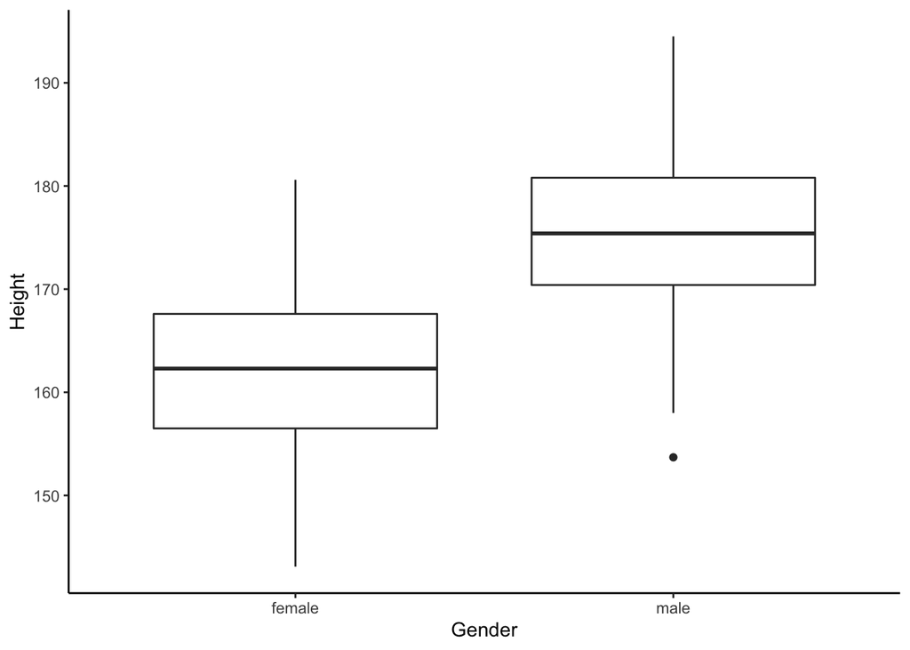

```r
p2 <- nhanes_tib %>% drop_na(Height,Gender) %>% filter(Age>=18) %>%
      ggplot( aes(y=Height, x=Gender)) + geom_boxplot() + theme_classic()
p2
```